# (Almost) Fully Customisable Choropleth Maps

Isi Avbulimen

10 September 2018

This document will demonstrate how to produce choropleth maps in R that can be customised in (almost) any way that you want. We’ll be mainly be using the ggplot2 package and as well as a few others.

# 1 Packages

First we want to load in the packages we’ll be using. `readr` and `dplyr` are for reading and manipulating data. `rgdal` is to read in our shapefiles, `ggplot2` to plot. We can use `classInt` to define intervals in our data and add colours to our map using `RcolorBrewer` or `viridis`.

```r
library(readr) # for reading and writing CSV files
library(dplyr) # for working with data
library(broom) #summarising data into a tibble
library(rgdal) # Reprojects data between co-ordinate systems (e.g. lat/long to BNG)
library(classInt) # defines intervals for data sets
library(ggplot2) # for plotting the map
library(RColorBrewer) # defines colour palettes
library(viridis) # more colour palettes
```

# 2 Load in Shapefiles and Data

We are going to be plotting England local authority data so will be using the corresponding shapefiles. We’ll load them using the `rgdal` package. Notice we don’t include the file extension:

```r
LAs <- rgdal::readOGR("Shapefiles","England_LAUA_2016")
```

This loads in as a large spatial polygons data frame. We can use `plot()` to see what it looks like:

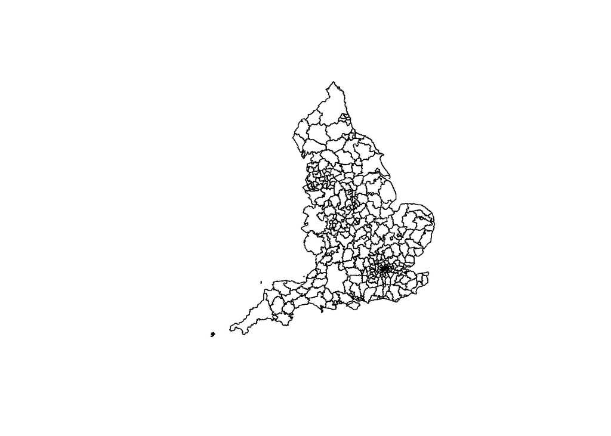

```r
plot(LAs)
```

Next we’ll load in the data we’ll be plotting. This is just some dummy data I created:

```r
dummy <- read_csv("Data/LA_dummy_data.csv")

head(dummy)
```

```
## # A tibble: 6 x 3
##   LA_Code   Local_Authority Percentage
##   <chr>     <chr>                <dbl>
## 1 E92000001 ENGLAND               80.2
## 2 E12000001 North East            45.2
## 3 E06000047 County Durham         88.1
## 4 E06000005 Darlington            77.0
## 5 E06000001 Hartlepool            16.0
## 6 E06000002 Middlesbrough         41.7
```

Now in order to plot the shapefile using ggplot2, we need to convert it from a spatial polygons data frame into a ggplot2-compatible data frame

```r
tidy_LAs <- broom::tidy(LAs, region = "LAD16CD")

head(tidy_LAs)
```

```
## # A tibble: 6 x 7
##      long     lat order hole  piece group       id
##     <dbl>   <dbl> <int> <lgl> <chr> <chr>       <chr>
## 1 447097  537152      1 FALSE 1     E06000001.1 E06000001
## 2 447229. 537033.     2 FALSE 1     E06000001.1 E06000001
## 3 447281. 537120.     3 FALSE 1     E06000001.1 E06000001
## 4 447378. 537095.     4 FALSE 1     E06000001.1 E06000001
## 5 447455. 537024.     5 FALSE 1     E06000001.1 E06000001
## 6 447550. 537078.     6 FALSE 1     E06000001.1 E06000001
```

The region argument is the variable we are using to split up the areas. Here it is “LAD16CD” which is the Local Authority code. This is turned into an id variable.

Now we will join our data with the converted shapefile so that we can plot it:

```r
map_data <- tidy_LAs %>%
  left_join(dummy, by = c("id" = "LA_Code"))

head(map_data)
```

```
## # A tibble: 6 x 9
##      long    lat order hole  piece group  id    Local_Authority Percentage
##     <dbl>  <dbl> <int> <lgl> <chr> <chr>  <chr> <chr>                <dbl>
## 1 447097  5.37e5     1 FALSE 1     E0600~ E060~ Hartlepool            16.0
## 2 447229. 5.37e5     2 FALSE 1     E0600~ E060~ Hartlepool            16.0
## 3 447281. 5.37e5     3 FALSE 1     E0600~ E060~ Hartlepool            16.0
## 4 447378. 5.37e5     4 FALSE 1     E0600~ E060~ Hartlepool            16.0
## 5 447455. 5.37e5     5 FALSE 1     E0600~ E060~ Hartlepool            16.0
## 6 447550. 5.37e5     6 FALSE 1     E0600~ E060~ Hartlepool            16.0
```

# 3 Plot the map

Using `geom_polygon`, we’ll plot the latitude against the longitude and then colour the map by the “Percentage” variable:

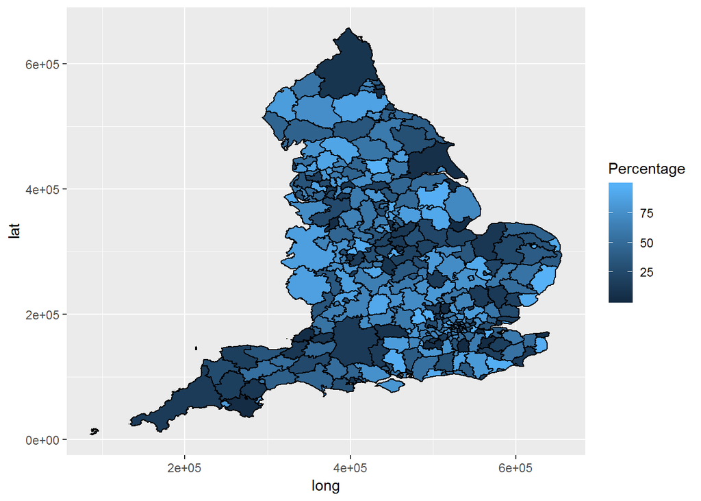

```r
map <- ggplot() +
  geom_polygon(data = map_data,
               aes(x = long, y = lat, group = group, fill = Percentage),
               col = "black")
map
```

Since we’re plotting a polygon with multiple rows of data, we need to overide the default ‘group’ and map it to a variable that has a different value for each group. In this case, when we converted our shapefile, a ‘group’ variable was created.

Great, we have a map! We don’t even need to define a colour scale as it’s using the ggplot2 default continuous colour sclae.

It looks a bit distorted though. We can fix this by using `coord_equal()` to force a 1:1 aspect ratio

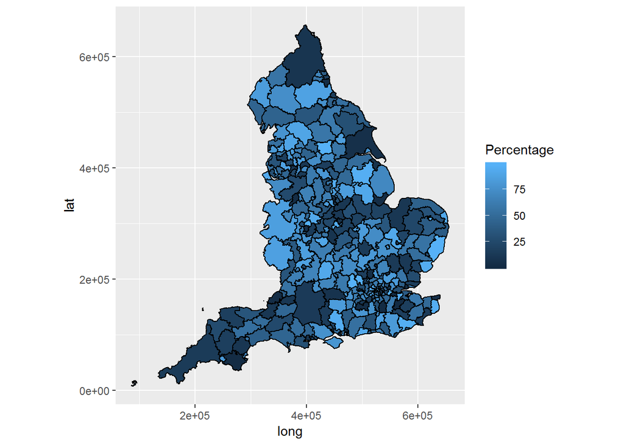

```r
map <- map + coord_equal()

map
```

Okay, we have a good aspect ratio now, but we have a horrible grey background and axes that we don’t really want. We can use the `theme()` function to set these things to blank:

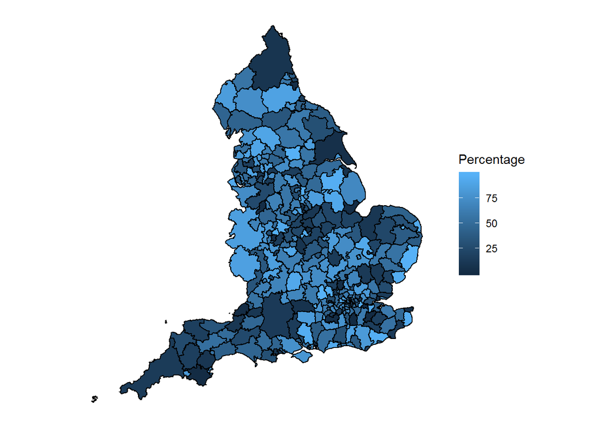

```r
map + theme(panel.background = element_blank(), # get rid of grey background
        axis.line = element_blank(), # get rid of axes lines
        axis.title = element_blank(), # get rid of axes labels
        axis.text = element_blank(), # get rid of the axes text
        axis.ticks = element_blank()) # get rid of the tick marks
```

There are many elements we can use within the theme function. If there are standard things we want in all of our maps, we can create a function so that we don’t need to call of these elements each time. We’ll base this function on the built-in `theme_minimal()`:

```r
theme_map <- theme_minimal() +
    theme(
      text = element_text(family = "sans"), # Arial font
      axis.line = element_blank(),
      axis.text = element_blank(),
      axis.ticks = element_blank(),
      axis.title = element_blank(),
      panel.grid = element_blank(),
      plot.background = element_blank(),
      panel.background = element_blank(),
      legend.background = element_blank(),
      panel.border = element_blank()
    )
```

So now we can plot the map using out new theme:

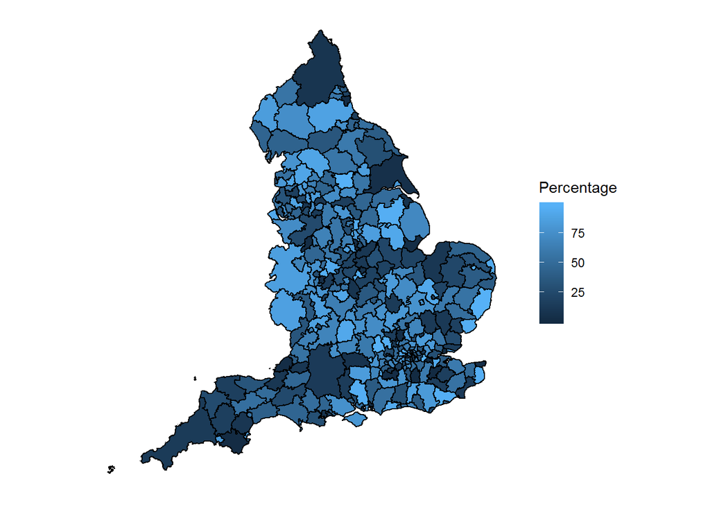

```r
map + theme_map
```

# 4 Customise your breaks

So now we have a good looking map. However the continuous scale isn’t very clear.

We can split the scale up to into discrete categories using the `cut_number()` function. This splits a numeric vector into intervals containing equal number of points. The first argument is the variable we are ‘cutting’ and the next argument is the number of intervals we want.

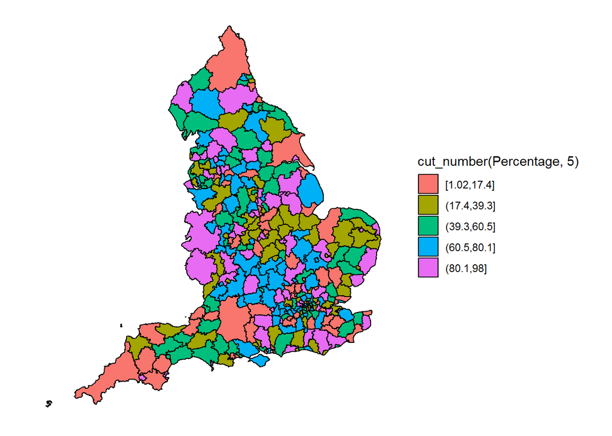

```r
ggplot() +
  geom_polygon(data = map_data,
               aes(x = long, y = lat, group = group, fill = cut_number(Percentage, 5)),
               col = "black") +
  coord_equal()+
  theme_map
```

Our colours now change to the default dicrete colour scale but we will look at how to change these a bit later.

If you want an even bigger of choice of breaks or you want to make your own, we can use `classIntervals()` function from the classInt package. This gives us commonly used methods for choosing univariate class intervals for mapping or other graphics purposes.

The different methods available are: “fixed”, “sd”, “equal”, “pretty”, “quantile”, “kmeans”, “hclust”, “bclust”, “fisher”, or “jenks”. We can use `?classIntervals` to get a full description of the different methods.

Here we are going to use ‘jenks’ breaks. This is a data clustering method designed to determine the best arrangement of values into different classes by reducing the variance within classes and maximising the variance between classes. It’s been checked for consistency with ArcView and ArcGIS.

```r
jenks_breaks <- classIntervals(dummy$Percentage, n=5, style = "jenks")
```

We can check our breaks like so:

```r
jenks_breaks$brks
```

```
## [1]  1.022535 20.296803 42.692727 62.109793 80.176022 99.800471
```

If you’re not sure whether the breaks you have created are right for your data, you can compare interval methods to one another. For example, let’s have a look at “equal” breaks:

```r
equal_breaks <- classIntervals(dummy$Percentage, n=5, style = "equal")
equal_breaks$brks
```

```
## [1]  1.022535 20.778123 40.533710 60.289297 80.044884 99.800471
```

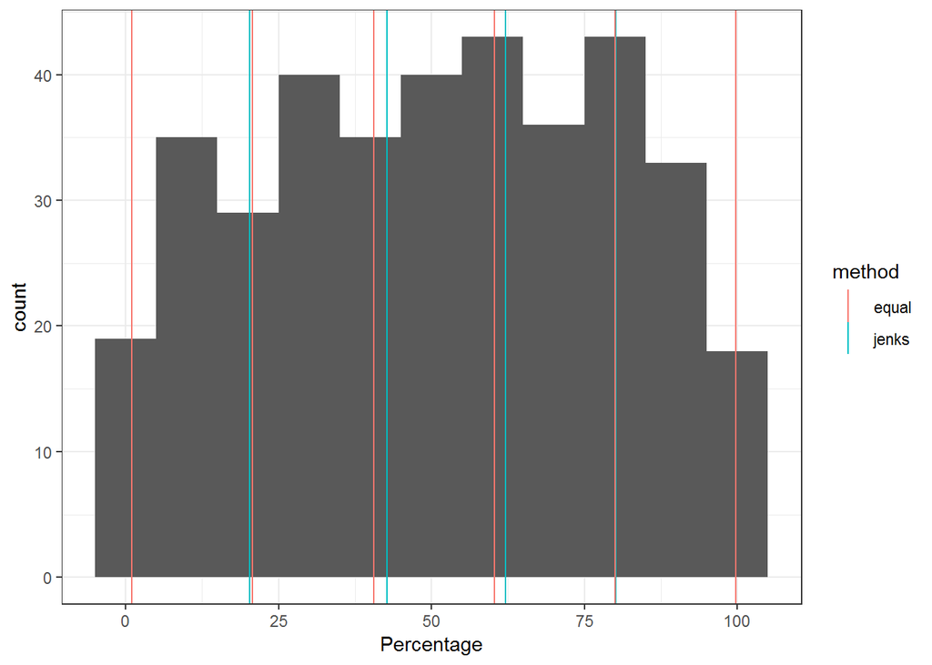

```r
vlines <- data.frame(
  jenks = jenks_breaks$brks,
  equal = equal_breaks$brks
) %>% tidyr::gather("method", "brks", jenks:equal)

ggplot(dummy, aes(x = Percentage))+
  geom_histogram(stat = "bin", binwidth = 10)+
  geom_vline(data = vlines, aes(xintercept = brks, color = method))+
  theme_bw()
```

Here we can see how much data falls into each interval and this may help us to make a better decision.

We’re going to go ahead and use “jenks” breaks for our map within the `cut()` rather than `cut_number()`:

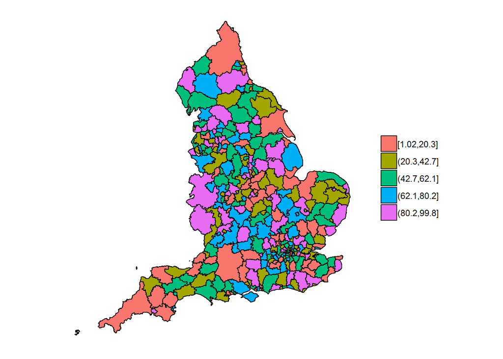

```r
ggplot() +
  geom_polygon(data = map_data,
               aes(x = long, y = lat, group = group,
                   fill = cut(x = Percentage, n = 5, breaks = jenks_breaks$brks,
                              include.lowest = TRUE)),
               col = "black") +
  coord_equal()+
  theme_map +
  theme(legend.title = element_blank()) #adding this to temporarily get rid of the legend title
```

# 5 Customise the labels

Here we’re going to define custom labels for our categories in the ‘a to b’ format.

```r
labels <- jenks_breaks$brks %>%
  round(0) %>%
  paste0(" to ", lead(.),"%") %>%
  head(-1)

labels
```

```
## [1] "1 to 20%"   "20 to 43%"  "43 to 62%"  "62 to 80%"  "80 to 100%"
```

Here we are taking each of the breaks, rounding them to the nearest whole number and concatenating with “to” and the next break, then removing the last label.

Now we can call our labels in the labels argument within `cut()`:

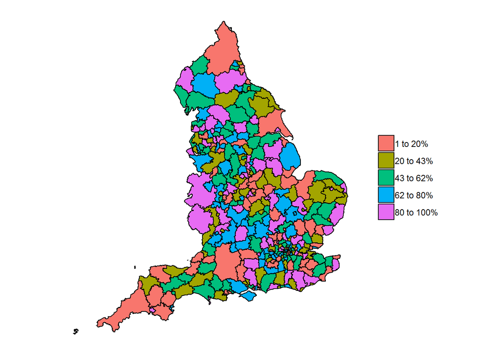

```r
ggplot() +
  geom_polygon(data = map_data,
               aes(x = long, y = lat, group = group,
                   fill = cut(x = Percentage, n = 5, breaks = jenks_breaks$brks,
                              labels = labels, include.lowest = TRUE)),
               col = "black") +
  coord_equal()+
  theme_map +
  theme(legend.title = element_blank())
```